# Practica_2

**Mauricio Montero**

[figure not shown]

## Multiple Linear Regression with Python (University admissions)

In this practical exercise, we will perform a predictive analysis on the likelihood of a student being admitted to a university. For this purpose, we will be provided with a dataset containing information related to metrics taken by a university in the USA.

# Ste 1: Load the necessary packages to execute the analysis.

```python
import pandas as pd
import numpy as np
import matplotlib.pyplot as plt
import seaborn as sns
from sklearn.model_selection import train_test_split
from sklearn.linear_model import LinearRegression
from sklearn.metrics import mean_squared_error, r2_score
from sklearn.impute import SimpleImputer
from sklearn.preprocessing import scale
```

# Step 2: Load the dataset and perform an exploration of the information using at least 5 methods

```
   Serial No.  GRE Score  TOEFL Score  University Rating  SOP  LOR   CGPA  \
0           1        337          118                  4  4.5   4.5  9.65
1           2        324          107                  4  4.0   4.5  8.87
2           3        316          104                  3  3.0   3.5  8.00
3           4        322          110                  3  3.5   2.5  8.67
4           5        314          103                  2  2.0   3.0  8.21

   Research  Chance of Admit
0         1              0.92
1         1              0.76
2         1              0.72
3         1              0.80
4         0              0.65
       Serial No.   GRE Score  TOEFL Score  University Rating         SOP  \
count  400.000000  400.000000   400.000000         400.000000  400.000000
mean   200.500000  316.807500   107.410000           3.087500    3.400000
std    115.614301   11.473646     6.069514           1.143728    1.006869
min      1.000000  290.000000    92.000000           1.000000    1.000000
25%    100.750000  308.000000   103.000000           2.000000    2.500000
50%    200.500000  317.000000   107.000000           3.000000    3.500000
75%    300.250000  325.000000   112.000000           4.000000    4.000000
max    400.000000  340.000000   120.000000           5.000000    5.000000

             LOR         CGPA    Research  Chance of Admit
count  400.000000  400.000000  400.000000        400.000000
mean     3.452500    8.598925    0.547500          0.724350
std      0.898478    0.596317    0.498362          0.142609
min      1.000000    6.800000    0.000000          0.340000
25%      3.000000    8.170000    0.000000          0.640000
50%      3.500000    8.610000    1.000000          0.730000
75%      4.000000    9.062500    1.000000          0.830000
max      5.000000    9.920000    1.000000          0.970000
Serial No.             int64
GRE Score              int64
TOEFL Score            int64
University Rating      int64
SOP                  float64
LOR                  float64
CGPA                 float64
Research               int64
Chance of Admit      float64
dtype: object
Serial No.           0
GRE Score            0
TOEFL Score          0
University Rating    0
SOP                  0
LOR                  0
CGPA                 0
Research             0
Chance of Admit      0
dtype: int64
```

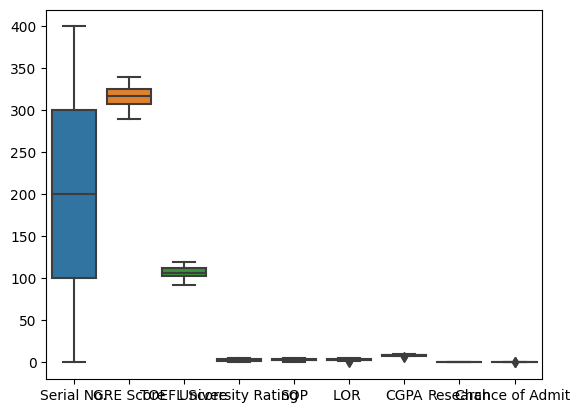

|  | Serial No. | GRE Score | TOEFL Score | University Rating | SOP | LOR | CGPA | Research | Chance of Admit |
| --- | --- | --- | --- | --- | --- | --- | --- | --- | --- |
| 0 | 1 | 337 | 118 | 4 | 4.5 | 4.5 | 9.65 | 1 | 0.92 |
| 1 | 2 | 324 | 107 | 4 | 4.0 | 4.5 | 8.87 | 1 | 0.76 |
| 2 | 3 | 316 | 104 | 3 | 3.0 | 3.5 | 8.00 | 1 | 0.72 |
| 3 | 4 | 322 | 110 | 3 | 3.5 | 2.5 | 8.67 | 1 | 0.80 |
| 4 | 5 | 314 | 103 | 2 | 2.0 | 3.0 | 8.21 | 0 | 0.65 |
| ... | ... | ... | ... | ... | ... | ... | ... | ... | ... |
| 395 | 396 | 324 | 110 | 3 | 3.5 | 3.5 | 9.04 | 1 | 0.82 |
| 396 | 397 | 325 | 107 | 3 | 3.0 | 3.5 | 9.11 | 1 | 0.84 |
| 397 | 398 | 330 | 116 | 4 | 5.0 | 4.5 | 9.45 | 1 | 0.91 |
| 398 | 399 | 312 | 103 | 3 | 3.5 | 4.0 | 8.78 | 0 | 0.67 |
| 399 | 400 | 333 | 117 | 4 | 5.0 | 4.0 | 9.66 | 1 | 0.95 |

```python
# df
data =pd.read_csv('Admisiones.csv')
# Display the first few rows of the dataset
print(data.head())

# Check the summary statistics of the dataset
print(data.describe())

# Check the data types of each column
print(data.dtypes)

# Check for missing values in the dataset
print(data.isnull().sum())

# Check for any outliers in the dataset
sns.boxplot(data=data)
plt.show()

data.info
data
```

## Step 3: Manipulate the data to check for missing values, outliers, etc.

```python
# Remove leading and trailing white spaces from headers
data.columns = data.columns.str.strip()
# df copy
copy1= data
#Delete NA rows
copy1.dropna(axis=0)
# There are no NA rows based on results

#Create Imputer mean
imp= SimpleImputer(missing_values=np.nan, strategy ='mean')

# New df
idf=pd.DataFrame(imp.fit_transform(data))

#Columns and index
idf.columns=data.columns
idf.index=data.index
data=idf
data.head()
```

|  | Serial No. | GRE Score | TOEFL Score | University Rating | SOP | LOR | CGPA | Research | Chance of Admit |
| --- | --- | --- | --- | --- | --- | --- | --- | --- | --- |
| 0 | 1.0 | 337.0 | 118.0 | 4.0 | 4.5 | 4.5 | 9.65 | 1.0 | 0.92 |
| 1 | 2.0 | 324.0 | 107.0 | 4.0 | 4.0 | 4.5 | 8.87 | 1.0 | 0.76 |
| 2 | 3.0 | 316.0 | 104.0 | 3.0 | 3.0 | 3.5 | 8.00 | 1.0 | 0.72 |
| 3 | 4.0 | 322.0 | 110.0 | 3.0 | 3.5 | 2.5 | 8.67 | 1.0 | 0.80 |
| 4 | 5.0 | 314.0 | 103.0 | 2.0 | 2.0 | 3.0 | 8.21 | 0.0 | 0.65 |

## Step 4: Execute an Exploratory Analysis

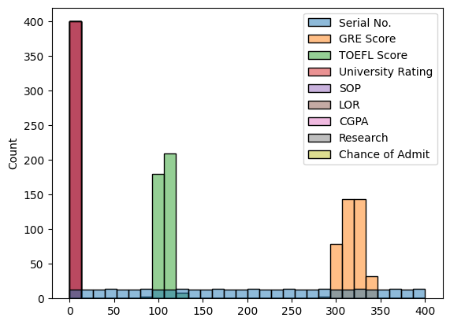

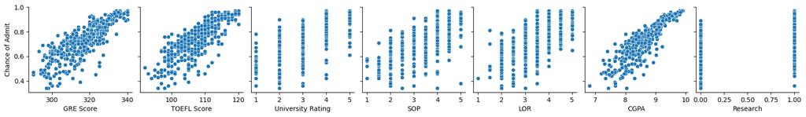

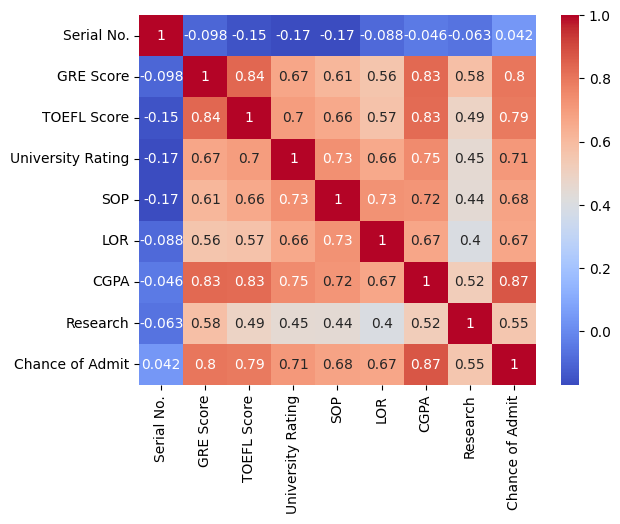

```python
# Visualize the distribution of each variable in the dataset
sns.histplot(data=data)
plt.show()
# Explore the relationship of the other variables against 'Chance of Admit'
sns.pairplot(data=data, x_vars=['GRE Score', 'TOEFL Score', 'University Rating', 'SOP', 'LOR', 'CGPA', 'Research'], y_vars='Chance of Admit', kind='scatter')
plt.show()

# Create a correlation matrix
correlation_matrix = data.corr()
sns.heatmap(correlation_matrix, annot=True, cmap='coolwarm')
plt.show()

# Remove any variables that are deemed unnecessary for the analysis (if applicable)
# In this case, 'Serial No.' might be unnecessary, so we can remove it
data = data.drop('Serial No.', axis=1)
```

Based on the previouse correlation matrix the predictor variables will be CGPA, GRE Score and TOEFL Score

## Step 5: Choose the predictor variables (x) and target variable (y).

```python
X=data[["CGPA", "TOEFL Score","GRE Score"]].values
y=data["Chance of Admit"].values
```

## Step 6: Split the data into a training set and a test set

```python
X_train, X_test, y_train, y_test = train_test_split(X, y, test_size=0.2, random_state=42)
```

## Step 7: Create the Multiple Linear Regression model and predict the results

```python
# Instantiate the Linear Regression model
reg = LinearRegression()

# Train the model using the training data
reg.fit(X_train, y_train)

# Predict the target variable using the test data
y_pred = reg.predict(X_test)
```

```python
# Evaluate the model using Mean Squared Error (MSE)
mse = mean_squared_error(y_test, y_pred)
print("Mean Squared Error:", mse)

# Evaluate the model using R-squared
r2 = r2_score(y_test, y_pred)
print("R-squared:", r2)
```

```
Mean Squared Error: 0.005262288512252049
R-squared: 0.7962198319810182
```

# Results:

1. An MSE of 0.0053 suggests that the model's predictions have relatively small errors on average
2. The R-squared value is approximately 0.7962, which means that around 79.62% of the variance in the 'Chance of Admit' can be explained by the independent variables included in the model